# Laboratorio Otros Modelos de Clasifiación IN5602 - Semestre Primavera 2021

Gabriela Mora

10-11-2021

# Machine Learning

La IA tiene por objetivo crear procesos automáticos que uno espera que funcionan de manera “inteligente” (la inteligencia humana), y dentro se ese marco se encuentra el Machine learning que tiene por objetivo no depender de un experto que decida cómo un humano resuelve un problema, si no que lo que uno trata de hacer es que con un algortimo general, a partir de experiencia (datos), pueda resolver el problema de manera automática.

En particular los modelos de clasificación de machine learning sirven para clasificar problemas dado el aprendizaje que obtuvo con datos previos en la etapa de entrenamiento, para luego probar el desempeño con los datos de testeo. El objetivo de los modelos de machine learning es que sean modelos que se puedan **generalizar**, esto quiere decir que si el modelo se encuentra con datos nuevos, el desempeño de nuestro modelo es bueno, o sea, clasifica de buena manera en este caso.

# Desarollo del laboratorio

## El Problema

Trabajarán con una base de datos sobre cáncer de mamas. El objetivo es desarrollar un modelo de ml que logre identificar cancer de mamas según las características presentadas en la base de datos. Esta posee 9 variables variables explicativas que se listan a continuación:

- Sample code number id number
- Clump Thickness 1 - 10
- Uniformity of Cell Size 1 - 10
- Uniformity of Cell Shape 1 - 10
- Marginal Adhesion 1 - 10
- Single Epithelial Cell Size 1 - 10
- Bare Nuclei 1 - 10
- Bland Chromatin 1 - 10
- Normal Nucleoli 1 - 10
- Mitoses 1 - 10
- Class: (2 for benign, 4 for malignant)

## Carga de datos y EDA

```r
# Librerias
library(caret)
library(readr)
cancer_mamas<-read.csv(file="C:/Users/enaga/Documents/Marketing 2/cancer.csv", header=TRUE, sep=";")

#Realice un EDA simple con el objetivo de ver las correlaciones entre la variable de interés y la clase
```

## Separación de la base en datos de entrenamiento y testeo

```r
#Se cambian valores de las clases
cancer_mamas$Class <- ifelse(cancer_mamas$Class==2, 'yes', 'no')

### Se definen los datos de entrenamiento y de test
train <- sample(1:nrow(cancer_mamas), size=round(0.8*nrow(cancer_mamas),0)) #indice aleatorio para los datos de entrenamiento

cancer_mamas.train <- cancer_mamas[train,]
cancer_mamas.test  <- cancer_mamas[-train,]
```

## K-Nearest Neighbors

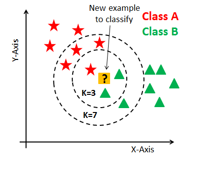

K-vecinos más cercanos (KNN) clasifica datos según los registros más “parecidos” que se configuraron en la etapa de entrenamiento del modelo, para medir “similitud” se usan métricas de distancia. Consideraciones en este modelo:

- Cuando hagan su tarea tendrán variables con categorías, en ese caso, recuerden pasar sus variables a valores que sean reconocibles por este modelo. Por ejemplo, a variables dummies si con variables nominales o escalar los valores si son variables ordinales.
- Al ser un modelo con métricas de distancia, consideren normalizar las magnitudes de todas estas. Ya que algunas pueden “pesar más” que otras. Para hacerlo apliquen $(preProcess = c("center","scale"))$

## Random Forest

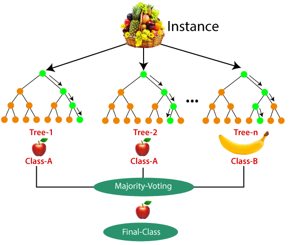

Random Forest se construyen utilizando los mismos principios fundamentales que los árboles de decisión, pero con la diferencia que en vez de crear sólo un árbol se contruyen varios. El mecanismo funciona separando el conjunto de entrenamiento en tantos subconjuntos como arboles de decisión se creen, los cuales tienen diferentes caracteríticas en sus nodos raíces, de decisión y de hoja, cuando el modelo clasifica este elige la clase más votada por los árboles.

## Support Vector Machines (SVM)

[figure not shown]

Suppot Vector Machines se formula como un problema de optimización matemática que busca encontrar el mejor hiperplano que me separa los casos. Entonces, si es esto lo que se busca, ¿cuál es el mejor hiperplano? es el que tiene el máximo margen. Considerariones en este modelo:

- Al igual que KNN funciona con métricas de distancia. Tengan ojo cuando usen variables con categorías en este modelo
- Para los más curiosos, hay SVM lineales y no lineales.
- Asegura óptimos globales a diferencia de los árboles de decisión
- Es más costoso de computar
- Mejores resultados de generalización.

## Métricas en modelos de clasificación

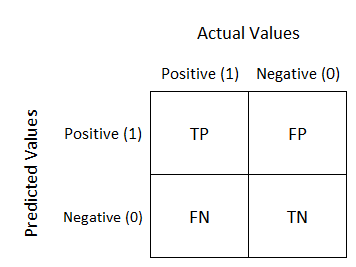

- *Accuracy* Indica sobre el total de elementos cuantos son predichos correctamente

$$Accuracy=\frac{TruePositives+TrueNegatives}{TruePositives+FalsePositives+TrueNegatives+FalseNegatives}$$

- *Precision* Indica respecto a los elementos predichos como positivos cuantos lo son efectivamente.

$$Precision=\frac{TruePositives}{TruePositives+FalsePositives}$$

- *Recall - Sensibility* Mide respecto a todos los elementos que efectivamente son positivos cuantos fueron predichos correctamente.

$$Recall=\frac{TruePositives}{TruePositives+FalseNegatives}$$

- *F-Measure* Entrega un promedio ponderado entre precision y recall. No posee interpretación intuitiva más alla de una media armonica entre precision y recall.

$$F_{measure}=\frac{2⋅Recall⋅Precision}{Recall+Presicion}$$

- Pdemos utilizar la librería MLmetrics para evaluar las otrás metricas no disponibles en caret o la pueden calcular a mano.

## Preguntas

Para responder estar preguntas sugiero ver la clase de otros modelos de clasificación y los códigos que se mostraron.

##### Pregunta 1

```r
# Seleccione 3 variables del dataset para generar las predicciones y argumente por qué son buenas variables para predecir un cáncer de mamas. Puede realizar un EDA o basarse en los gráficos ya incluidos.
# Determine 2 métricas para comparar los modelos, justifique su elección.
```

[output not shown]

[output not shown]

##### Pregunta 2

```r
# Corra 2 modelos de clasificación use las variables seleccionadas anteriormente para predecir la existencia de cáncer de mamas.
# Cálcule para cada modelo las metricas seleccionadas para el set de entrenamiento y de testeo, además grafique la matriz de confusión para ambos.
# Comente sobre los resultados, ¿se observa overfitting o underfitting?
# confusionMatrix(pred_vali, vali$target)
```

##### Pregunta 3

```r
# Compare los modelos a través de métricas presentadas en el laboratorio. ¿Con que modelo se quedaría?
```